# Part 6: Over 10K - All Years

# 1 Introduction

### 1.0.1 Background

The following is summary information on complete cases with salaries over $10,000.

### 1.0.2 Libraries

Load required libraries.

```r
library(proto)
library(gsubfn)
library(RSQLite)
library(knitr)
library(data.table)
library(plyr)
library(dplyr)
library(sqldf)
library(ggplot2)
library(RColorBrewer)
library(grid)
library(ggrepel)
library(plotly)
library(kableExtra)
library(tidyr)

# required files chunk 1
# df10.csv

# required files chunk 12
```

# 2 Import and clean

### 2.0.1 Import complete cases with salaries over 10K.

### 2.0.2 Clean data

Remove all cases where Community Boards are the agencies. This is to provide a more accurate list of agencies as there are 59 Community Boards and each is considered its own agency, although in reality these are small offices.

Change the value of the Administrative Staff Analyst title to remove the trailing parenthesis.

```r
#import csv of all complete cases over 10k
df10<- data.frame(read.csv("df10.csv"),stringsAsFactors = FALSE, strip.white=TRUE)

#rename dataframe
df10a<-df10

#remove community boards
df<-df10a[- grep("COMMUNITY BOARD", df10a$agency),]

#change class to character
df$Description <- as.character(df$Description)

#clean title description to remove parenthesis
df$Description[df$Description == "ADMINISTRATIVE STAFF ANALYST ("] <- "ADMINISTRATIVE STAFF ANALYST"

# Intial results indicated this may need cleanup because there are not 84 agencies-- some spaces in the agency names are causing agencies to appear twice. The following trim function successfully reduced the number of unique agencies.
trim <- function (x) gsub("^\\s+|\\s+$", "", x)
df$agency <- trim(df$agency)

#show structure
str(df)
```

```
## 'data.frame':    414504 obs. of  22 variables:
##  $ X                : int  274305 274306 274307 274308 274309 822393 822394 822395 822396 822397 ...
##  $ title            : Factor w/ 608 levels "0527A","54503",..: 1 1 1 1 1 82 82 82 82 82 ...
##  $ year             : int  2014 2016 2015 2016 2015 2016 2014 2015 2017 2014 ...
##  $ agencycode       : int  2 2 2 2 2 56 56 56 56 56 ...
##  $ empname          : Factor w/ 194696 levels "A   AANOUZ","A   AANOUZ         ",..: 100576 71908 162126 3173 30725 167395 119392 67291 152201 53166 ...
##  $ agency           : chr  "OFFICE OF THE MAYOR" "OFFICE OF THE MAYOR" "OFFICE OF THE MAYOR" "OFFICE OF THE MAYOR" ...
##  $ payclass         : Factor w/ 14 levels "A","A ","BW",..: 1 1 1 1 1 4 4 4 5 4 ...
##  $ sal              : num  125000 165609 65000 56650 128125 ...
##  $ Description      : chr  "Research Projects Coor(MA)-MGR" "Research Projects Coor(MA)-MGR" "Research Projects Coor(MA)-MGR" "Research Projects Coor(MA)-MGR" ...
##  $ CountSubTitles   : int  1 1 1 1 1 56 56 56 56 56 ...
##  $ Min.MinRate      : int  53373 53373 53373 53373 53373 41975 41975 41975 41975 41975 ...
##  $ Max.MaxRate      : int  212614 212614 212614 212614 212614 76488 76488 76488 76488 76488 ...
##  $ SalaryMinMaxValid: Factor w/ 1 level "ValidSalary": 1 1 1 1 1 1 1 1 1 1 ...
##  $ MultipleSubtitles: Factor w/ 2 levels "MultipleTitles",..: 2 2 2 2 2 1 1 1 1 1 ...
##  $ PayType          : Factor w/ 3 levels "AnnualSalary",..: 1 1 1 1 1 1 1 1 1 1 ...
##  $ PayPeriod        : Factor w/ 2 levels "Annual","Seasonal": 1 1 1 1 1 1 1 1 1 1 ...
##  $ UnionCode        : int  883 883 883 883 883 79 79 79 79 79 ...
##  $ UnionName        : Factor w/ 80 levels "ACCOUNTING AND EDP TITLES DC37",..: 44 44 44 44 44 53 53 53 53 53 ...
##  $ BargUnit         : Factor w/ 28 levels "ADWA","CCA","CEA",..: 15 15 15 15 15 17 17 17 17 17 ...
##  $ BargDesc         : Factor w/ 28 levels "Alliance ofTheatrical&StageEEs",..: 15 15 15 15 15 17 17 17 17 17 ...
##  $ TitleStatus      : Factor w/ 2 levels "ActiveTitle",..: 1 1 1 1 1 1 1 1 1 1 ...
##  $ strip.white      : logi  TRUE TRUE TRUE TRUE TRUE TRUE ...
```

# 3 All titles

### 3.0.1 Titles available in the most agencies

```r
dfallyears<-df

df %>%
  group_by(Description) %>%
  summarise(count = n_distinct(agency))%>%
  arrange(desc(count))%>%
  top_n(20)%>%
  kable("html") %>%
  kable_styling()
```

| Description | count |
| --- | --- |
| COMMUNITY ASSOCIATE | 63 |
| COMMUNITY COORDINATOR | 61 |
| EXECUTIVE AGENCY COUNSEL | 55 |
| COMMUNITY ASSISTANT | 47 |
| AGENCY CHIEF CONTRACTING OFFIC | 28 |
| ADMINISTRATIVE PROJECT MANAGER | 27 |
| MOTOR VEHICLE OPERATOR | 23 |
| RESEARCH ASSISTANT | 23 |
| ADMINISTRATIVE PROCUREMENT ANA | 22 |
| ADMINISTRATIVE LABOR RELATIONS | 21 |
| GRAPHIC ARTIST | 19 |
| CITY CUSTODIAL ASSISTANT | 15 |
| MOTOR VEHICLE SUPERVISOR | 14 |
| ADMINISTRATIVE CONSTRUCTION PR | 13 |
| ASSOCIATE PUBLIC INFORMATION | 13 |
| CUSTOMER INFORMATION REP | 13 |
| PUBLIC RECORDS AIDE | 12 |
| PUBLIC RECORDS OFFICER | 12 |
| SPACE ANALYST | 12 |
| CUSTODIAN | 11 |
| MEDIA SERVICES TECHNICIAN | 11 |
| SPECIAL OFFICER | 11 |

### 3.0.2 All titles - highest paid titles in 2017

```r
#salaries above 10k

# highest paid titles in 2017
df17<- dfallyears[dfallyears$year==2017,]

topsal<-df17 %>%
  group_by(Description) %>%
  mutate(Count = n()) %>%
  group_by(title, Description,  Count) %>%
  summarise_at(vars(sal), funs(mean(., na.rm=TRUE)  ))%>%
  arrange(desc(sal))

kable(head(topsal,20))
```

| title | Description | Count | sal |
| --- | --- | --- | --- |
| 94450 | CHIEF OF STAFF (CITY COUNCIL) | 1 | 251763 |
| 94465 | EXECUTIVE DIRECTOR (CAMPAIGN F | 1 | 244840 |
| 94488 | CHAIR (HA) | 1 | 231684 |
| 82977 | FIRST DEPUTY COMMISSIONER (DCA | 1 | 226366 |
| 94310 | DIRECTOR OF THE OFFICE OF COLL | 1 | 226366 |
| 94312 | COMMISSIONER OF PARKS & RECREA | 1 | 226366 |
| 94323 | COMMISSIONER OF FINANCE | 1 | 226366 |
| 94355 | COMMISSIONER OF BUILDINGS | 1 | 226366 |
| 94357 | COMMISSIONER OF HEALTH | 1 | 226366 |
| 94358 | COMMISSIONER OF ENVIRONMENTAL | 1 | 226366 |
| 94361 | COMMISSIONER OF TRANSPORTATION | 1 | 226366 |
| 94362 | COMMISSIONER OF HOUSING PRESER | 1 | 226366 |
| 94363 | COMMISSIONER OF SANITATION | 1 | 226366 |
| 94370 | HUMAN RESOURCES ADMINISTRATOR | 1 | 226366 |
| 94468 | EXECUTIVE DIRECTOR (FISA) | 1 | 226366 |
| 94513 | COMMISSIONER OF DEPT OF INFO T | 1 | 226366 |
| 94518 | COMMISSIONER OF CHILDREN’S SER | 2 | 226366 |
| 94520 | COMMISSIONER OF DESIGN & CONST | 1 | 226366 |
| 94522 | COMMISSIONER OF CITYWIDE ADMIN | 1 | 226366 |
| 94525 | CHAIR (BIC) | 1 | 226366 |

### 3.0.3 All titles - highest paid titles in 2017, excluding Commissioners

```r
#remove commissioners
df17a<-df17[- grep("COMMISSIONER", df17$Description),]

topsal1<-df17a %>%
  group_by(Description) %>%
  mutate(Count = n()) %>%
  group_by(title, Description,  Count) %>%
  summarise_at(vars(sal), funs(mean(., na.rm=TRUE)  ))%>%
  arrange(desc(sal))

kable(head(topsal1,20))
```

| title | Description | Count | sal |
| --- | --- | --- | --- |
| 94450 | CHIEF OF STAFF (CITY COUNCIL) | 1 | 251763 |
| 94465 | EXECUTIVE DIRECTOR (CAMPAIGN F | 1 | 244840 |
| 94488 | CHAIR (HA) | 1 | 231684 |
| 94310 | DIRECTOR OF THE OFFICE OF COLL | 1 | 226366 |
| 94370 | HUMAN RESOURCES ADMINISTRATOR | 1 | 226366 |
| 94468 | EXECUTIVE DIRECTOR (FISA) | 1 | 226366 |
| 94525 | CHAIR (BIC) | 1 | 226366 |
| 95450 | CHIEF CITY MEDICAL EXAMINER | 1 | 226366 |
| 7026P | CHIEF OF DEPARTMENT | 1 | 225826 |
| 70388 | CHIEF OF DEPARTMENT (FDNY) | 1 | 225826 |
| 95451 | DEPUTY CHIEF CITY MEDICAL EXAM | 5 | 224749 |
| 7026H | CAPTAIN DETAILED AS CHIEF OF D | 1 | 224453 |
| 7026I | CAPTAIN DETAILED AS CHIEF OF I | 1 | 224453 |
| 7026J | CAPTAIN DETAILED AS CHIEF OF O | 2 | 224453 |
| 7026K | CAPTAIN DETAILED AS CHIEF OF P | 2 | 224453 |
| 7026L | CAPTAIN DETAILED AS CHIEF OF P | 2 | 224453 |
| 7026M | CHIEF INSPECTOR | 1 | 224453 |
| 7026N | CAPTAIN DETAILED AS CHIEF OF O | 2 | 224453 |
| 7026R | CHIEF OF THE HOUSING BUREAU | 1 | 224453 |
| 7026S | CHIEF OF THE TRANSIT BUREAU | 1 | 224453 |

# 4 Select titles only

### 4.0.1 Subset select titles for cross-agency comparison

Issue: A title may have more than one title code, partly due to defunct title codes or special agency designations. To account for this, the grouping is performed on the Description value.

```r
dfsub1<- df[df$Description %in% c(
  "COMMUNITY ASSOCIATE",
  "ADMINISTRATIVE STAFF ANALYST",
  "COMMUNITY COORDINATOR",
  "PRINCIPAL ADMINISTRATIVE ASSOC",
  "CLERICAL ASSOCIATE",
  "COMPUTER SYSTEMS MANAGER",
  "EXECUTIVE AGENCY COUNSEL",
  "ADM MANAGER-NON-MGRL FRM M1/M2",
  "ASSOCIATE STAFF ANALYST",
  "COMMUNITY ASSISTANT",
  "SECRETARY",
  "ADMINISTRATIVE PUBLIC INFORMAT",
  "AGENCY ATTORNEY",
  "COMPUTER SPECIALIST (SOFTWARE)",
  "STAFF ANALYST",
  "ADMINISTRATIVE MANAGER",
  "COMPUTER ASSOC (SOFTWARE)",
  "PROCUREMENT ANALYST",
  "COMPUTER ASSOC (OPERATIONS)",
  "ACCOUNTANT"
  ), ]

str(dfsub1)
```

```
## 'data.frame':    37512 obs. of  22 variables:
##  $ X                : int  1155005 1155006 1155007 1155008 1155009 1155010 1155011 1155012 1155013 1155014 ...
##  $ title            : Factor w/ 608 levels "0527A","54503",..: 435 435 435 435 435 435 435 435 435 435 ...
##  $ year             : int  2017 2014 2014 2016 2015 2014 2015 2014 2016 2016 ...
##  $ agencycode       : int  69 56 868 996 820 996 996 740 2 866 ...
##  $ empname          : Factor w/ 194696 levels "A   AANOUZ","A   AANOUZ         ",..: 153326 153807 54888 129492 169174 149443 80070 165673 97429 90665 ...
##  $ agency           : chr  "HRA/DEPARTMENT OF SOCIAL S" "POLICE DEPARTMENT" "DEPARTMENT OF CITYWIDE ADM" "N.Y.C. HOUSING AUTHORITY" ...
##  $ payclass         : Factor w/ 14 levels "A","A ","BW",..: 2 1 1 1 1 1 1 1 1 1 ...
##  $ sal              : num  149789 113365 120000 92700 84062 ...
##  $ Description      : chr  "EXECUTIVE AGENCY COUNSEL" "EXECUTIVE AGENCY COUNSEL" "EXECUTIVE AGENCY COUNSEL" "EXECUTIVE AGENCY COUNSEL" ...
##  $ CountSubTitles   : int  2 2 2 2 2 2 2 2 2 2 ...
##  $ Min.MinRate      : int  53373 53373 53373 53373 53373 53373 53373 53373 53373 53373 ...
##  $ Max.MaxRate      : int  212614 212614 212614 212614 212614 212614 212614 212614 212614 212614 ...
##  $ SalaryMinMaxValid: Factor w/ 1 level "ValidSalary": 1 1 1 1 1 1 1 1 1 1 ...
##  $ MultipleSubtitles: Factor w/ 2 levels "MultipleTitles",..: 1 1 1 1 1 1 1 1 1 1 ...
##  $ PayType          : Factor w/ 3 levels "AnnualSalary",..: 1 1 1 1 1 1 1 1 1 1 ...
##  $ PayPeriod        : Factor w/ 2 levels "Annual","Seasonal": 1 1 1 1 1 1 1 1 1 1 ...
##  $ UnionCode        : int  772 772 772 772 772 772 772 772 772 772 ...
##  $ UnionName        : Factor w/ 80 levels "ACCOUNTING AND EDP TITLES DC37",..: 48 48 48 48 48 48 48 48 48 48 ...
##  $ BargUnit         : Factor w/ 28 levels "ADWA","CCA","CEA",..: 15 15 15 15 15 15 15 15 15 15 ...
##  $ BargDesc         : Factor w/ 28 levels "Alliance ofTheatrical&StageEEs",..: 15 15 15 15 15 15 15 15 15 15 ...
##  $ TitleStatus      : Factor w/ 2 levels "ActiveTitle",..: 1 1 1 1 1 1 1 1 1 1 ...
##  $ strip.white      : logi  TRUE TRUE TRUE TRUE TRUE TRUE ...
```

```r
dfsub1 %>%
  group_by(Description) %>%
  summarise(count = n_distinct(agency))%>%
  arrange(desc(count))%>%
  top_n(20)%>%
  kable("html") %>%
  kable_styling()
```

| Description | count |
| --- | --- |
| COMMUNITY ASSOCIATE | 63 |
| COMMUNITY COORDINATOR | 61 |
| EXECUTIVE AGENCY COUNSEL | 55 |
| COMMUNITY ASSISTANT | 47 |

### 4.0.2 Select titles - highest average salaries

Group select titles with average salary and count of title.

Arrange by descending average salary across all years.

```r
salbytitle1<-dfsub1 %>%
  group_by(Description) %>%
  mutate(Count = n()) %>%
  group_by(Description,  Count) %>%
  summarise_at(vars(sal), funs(mean(., na.rm=TRUE)  ))%>%
  arrange(desc(sal))

kable(head(salbytitle1))
```

| Description | Count | sal |
| --- | --- | --- |
| EXECUTIVE AGENCY COUNSEL | 1984 | 125927.59 |
| COMMUNITY COORDINATOR | 11792 | 62545.40 |
| COMMUNITY ASSOCIATE | 19279 | 44095.23 |
| COMMUNITY ASSISTANT | 4457 | 34635.28 |

### 4.0.3 Select titles - average salaries by title and year

Group select titles with average salary and count of title, by year.

Arrange by title.

```r
salbytitle2<-dfsub1 %>%
  group_by(Description, year) %>%
  mutate(Count = n()) %>%
  group_by(Description, year, Count) %>%
  summarise_at(vars(sal), funs(mean(., na.rm=TRUE)  ))%>%
  arrange(Description)

kable(salbytitle2)
```

| Description | year | Count | sal |
| --- | --- | --- | --- |
| COMMUNITY ASSISTANT | 2014 | 1059 | 33534.27 |
| COMMUNITY ASSISTANT | 2015 | 1131 | 34283.12 |
| COMMUNITY ASSISTANT | 2016 | 1079 | 35337.83 |
| COMMUNITY ASSISTANT | 2017 | 1188 | 35313.90 |
| COMMUNITY ASSOCIATE | 2014 | 4113 | 42498.86 |
| COMMUNITY ASSOCIATE | 2015 | 4935 | 43292.98 |
| COMMUNITY ASSOCIATE | 2016 | 4789 | 45108.02 |
| COMMUNITY ASSOCIATE | 2017 | 5442 | 45137.98 |
| COMMUNITY COORDINATOR | 2014 | 1902 | 60819.30 |
| COMMUNITY COORDINATOR | 2015 | 2560 | 61427.02 |
| COMMUNITY COORDINATOR | 2016 | 3256 | 63185.05 |
| COMMUNITY COORDINATOR | 2017 | 4074 | 63542.80 |
| EXECUTIVE AGENCY COUNSEL | 2014 | 433 | 116984.68 |
| EXECUTIVE AGENCY COUNSEL | 2015 | 499 | 124601.88 |
| EXECUTIVE AGENCY COUNSEL | 2016 | 488 | 129527.76 |
| EXECUTIVE AGENCY COUNSEL | 2017 | 564 | 130851.20 |

### 4.0.4 Select titles - average salaries by title and year, with year comparison

```r
salbytitle3<-salbytitle2%>%
  select(Description, year, sal)%>%
  spread(year, sal)

kable(salbytitle3)
```

| Description | 2014 | 2015 | 2016 | 2017 |
| --- | --- | --- | --- | --- |
| COMMUNITY ASSISTANT | 33534.27 | 34283.12 | 35337.83 | 35313.90 |
| COMMUNITY ASSOCIATE | 42498.86 | 43292.98 | 45108.02 | 45137.98 |
| COMMUNITY COORDINATOR | 60819.30 | 61427.02 | 63185.05 | 63542.80 |
| EXECUTIVE AGENCY COUNSEL | 116984.68 | 124601.88 | 129527.76 | 130851.20 |

### 4.0.5 Select titles - average salaries by agency and year, with count

Group agencies represented in these select titles with average salary and count of title, by year.

```r
salbyagency1<-dfsub1 %>%
  group_by(agency, year) %>%
  mutate(Count = n()) %>%
  group_by(agency, year, Count) %>%
  summarise_at(vars(sal), funs(mean(., na.rm=TRUE)  ))%>%
  arrange(agency)

kable(salbyagency1)
```

| agency | year | Count | sal |
| --- | --- | --- | --- |
| ADMINISTRATION FOR CHILDRE | 2014 | 341 | 58246.94 |
| ADMINISTRATION FOR CHILDRE | 2015 | 369 | 59936.88 |
| ADMINISTRATION FOR CHILDRE | 2016 | 423 | 61795.36 |
| ADMINISTRATION FOR CHILDRE | 2017 | 500 | 63479.65 |
| BOARD OF CORRECTIONS | 2014 | 1 | 46762.00 |
| BOARD OF CORRECTIONS | 2015 | 1 | 56229.00 |
| BOARD OF CORRECTIONS | 2016 | 2 | 57916.00 |
| BOARD OF CORRECTIONS | 2017 | 6 | 65745.33 |
| BOROUGH PRESIDENT-BRONX | 2014 | 23 | 59217.87 |
| BOROUGH PRESIDENT-BRONX | 2015 | 26 | 60024.73 |
| BOROUGH PRESIDENT-BRONX | 2016 | 25 | 61506.68 |
| BOROUGH PRESIDENT-BRONX | 2017 | 23 | 61585.22 |
| BOROUGH PRESIDENT-BROOKLYN | 2014 | 27 | 54388.44 |
| BOROUGH PRESIDENT-BROOKLYN | 2015 | 32 | 55039.19 |
| BOROUGH PRESIDENT-BROOKLYN | 2016 | 30 | 59301.77 |
| BOROUGH PRESIDENT-BROOKLYN | 2017 | 30 | 60777.57 |
| BOROUGH PRESIDENT-MANHATTA | 2014 | 12 | 51185.23 |
| BOROUGH PRESIDENT-MANHATTA | 2015 | 16 | 53283.17 |
| BOROUGH PRESIDENT-MANHATTA | 2016 | 21 | 56287.32 |
| BOROUGH PRESIDENT-MANHATTA | 2017 | 25 | 55895.11 |
| BOROUGH PRESIDENT-QUEENS | 2014 | 24 | 47401.33 |
| BOROUGH PRESIDENT-QUEENS | 2015 | 28 | 50020.86 |
| BOROUGH PRESIDENT-QUEENS | 2016 | 27 | 51845.37 |
| BOROUGH PRESIDENT-QUEENS | 2017 | 28 | 53283.54 |
| BOROUGH PRESIDENT-RICHMOND | 2014 | 12 | 61546.17 |
| BOROUGH PRESIDENT-RICHMOND | 2015 | 13 | 62582.77 |
| BOROUGH PRESIDENT-RICHMOND | 2016 | 12 | 64375.33 |
| BOROUGH PRESIDENT-RICHMOND | 2017 | 13 | 64808.00 |
| BUSINESS INTEGRITY COMMISS | 2014 | 33 | 64065.82 |
| BUSINESS INTEGRITY COMMISS | 2015 | 43 | 63076.12 |

[output cut: 243 more lines]

### 4.0.6 Select titles - average salaries by agency and year, with year comparison

```r
salbyagency2<-salbyagency1%>%
  select(agency, year, sal)%>%
  spread(year, sal)

kable(salbyagency2)
```

| agency | 2014 | 2015 | 2016 | 2017 |
| --- | --- | --- | --- | --- |
| ADMINISTRATION FOR CHILDRE | 58246.94 | 59936.88 | 61795.36 | 63479.65 |
| BOARD OF CORRECTIONS | 46762.00 | 56229.00 | 57916.00 | 65745.33 |
| BOROUGH PRESIDENT-BRONX | 59217.87 | 60024.73 | 61506.68 | 61585.22 |
| BOROUGH PRESIDENT-BROOKLYN | 54388.44 | 55039.19 | 59301.77 | 60777.57 |
| BOROUGH PRESIDENT-MANHATTA | 51185.23 | 53283.17 | 56287.32 | 55895.11 |
| BOROUGH PRESIDENT-QUEENS | 47401.33 | 50020.86 | 51845.37 | 53283.54 |
| BOROUGH PRESIDENT-RICHMOND | 61546.17 | 62582.77 | 64375.33 | 64808.00 |
| BUSINESS INTEGRITY COMMISS | 64065.82 | 63076.12 | 62449.72 | 62200.63 |
| CAMPAIGN FINANCE BOARD | 175636.00 | 186347.00 | 169622.00 | 177524.67 |
| CITY CLERK | 66740.38 | 68191.56 | 76036.00 | 66064.73 |
| CIVIL SERVICE COMMISSION | 36236.33 | 38881.33 | 67373.25 | 70159.00 |
| CIVILIAN COMPLAINT REVIEW | 74976.27 | 73738.72 | 75292.95 | 83585.18 |
| COMMISSION ON HUMAN RIGHTS | 42710.67 | 81033.12 | 80709.39 | 79167.21 |
| CONFLICTS OF INTEREST BOAR | 101402.88 | 113035.78 | 93949.36 | 100228.00 |
| DEPARTMENT FOR THE AGING | 52479.87 | 54478.03 | 57908.07 | 57983.83 |
| DEPARTMENT OF BUILDINGS | 56956.29 | 60323.01 | 66432.52 | 67872.53 |
| DEPARTMENT OF BUSINESS SER | 54331.48 | 56213.44 | 61854.42 | 61981.70 |
| DEPARTMENT OF CITY PLANNIN | 86395.00 | 76639.67 | 61898.03 | 62263.21 |
| DEPARTMENT OF CITYWIDE ADM | 51105.00 | 55550.73 | 57086.74 | 56249.41 |
| DEPARTMENT OF CONSUMER AFF | 49082.62 | 50850.12 | 54276.62 | 55856.89 |
| DEPARTMENT OF CORRECTION | 93681.00 | 73363.43 | 71922.88 | 66030.11 |
| DEPARTMENT OF CULTURAL AFF | 67318.71 | 70145.06 | 70672.60 | 69735.81 |
| DEPARTMENT OF DESIGN AND C | 82713.18 | 70835.49 | 71289.37 | 64722.30 |
| DEPARTMENT OF EDUCATION | 44705.31 | 46155.57 | 48317.87 | 49045.55 |
| DEPARTMENT OF ENVIRONMENTA | 66451.13 | 61865.25 | 64452.10 | 66815.39 |
| DEPARTMENT OF FINANCE | 95606.88 | 101860.90 | 100847.68 | 97823.84 |
| DEPARTMENT OF HEALTH AND M | 62062.32 | 63070.20 | 60049.63 | 59277.73 |
| DEPARTMENT OF HOMELESS SER | 43733.41 | 46012.38 | 48256.93 | 47498.37 |
| DEPARTMENT OF INFORMATION | 64068.24 | 68756.95 | 61191.88 | 64079.85 |
| DEPARTMENT OF INVESTIGATIO | 46738.00 | 40718.29 | 48759.47 | 50035.09 |
| DEPARTMENT OF PARKS & RECR | 56077.43 | 58409.03 | 60949.05 | 62236.06 |
| DEPARTMENT OF PROBATION | 55872.08 | 58607.86 | 61802.48 | 65364.28 |
| DEPARTMENT OF SANITATION | 50849.97 | 51843.58 | 54021.59 | 55479.43 |
| DEPARTMENT OF TRANSPORTATI | 58277.57 | 56794.18 | 60036.47 | 58950.73 |
| DEPARTMENT OF VETERANS’ SE | NA | NA | 56021.73 | 56204.50 |
| DEPARTMENT OF YOUTH AND CO | 56954.50 | 57757.65 | 61339.94 | 63071.34 |
| DEPT. OF RECORDS AND INFOR | 34311.50 | 42137.20 | 51837.80 | 60656.89 |
| DISTRICT ATTORNEY-BRONX CO | 38593.01 | 39382.42 | 41331.59 | 41423.06 |
| DISTRICT ATTORNEY-KINGS CO | 42378.04 | 43471.66 | 45399.78 | 45001.42 |
| DISTRICT ATTORNEY-NEW YORK | 48832.69 | 49396.24 | 52028.43 | 51124.75 |
| DISTRICT ATTORNEY-QUEENS C | 41447.97 | 41787.91 | 42301.64 | 41437.99 |
| DISTRICT ATTORNEY-RICHMOND | 47685.78 | 48939.00 | 53933.50 | 55845.00 |
| DISTRICT ATTORNEY - SPECIA | 57033.73 | 59606.22 | 62455.31 | 62047.50 |
| EQUAL EMPLOYMENT PRACTICES | 64921.25 | 64633.00 | 64967.70 | 64651.00 |
| FINANCIAL INFORMATION SERV | 76584.25 | 83478.17 | 79248.85 | 79752.66 |
| FIRE DEPARTMENT | 75779.69 | 74756.30 | 72424.93 | 75490.75 |
| HOUSING PRESERVATION & DEV | 49719.05 | 50540.86 | 54362.40 | 56217.74 |
| HRA/DEPARTMENT OF SOCIAL S | 53707.25 | 53490.79 | 56773.80 | 58190.21 |
| LANDMARKS PRESERVATION COM | 49650.00 | 44892.17 | 47101.00 | 45792.25 |
| LAW DEPARTMENT | 59524.50 | 61012.50 | 56635.30 | 56751.73 |
| MAYOR’S OFFICE OF CONTRACT | NA | NA | 113957.50 | 130000.00 |
| N.Y.C. HOUSING AUTHORITY | 54121.88 | 58308.70 | 61783.53 | 62710.96 |
| NEW YORK CITY FIRE PENSION | NA | NA | NA | 95367.00 |
| NYC EMPLOYEES’ RETIREMENT | 61605.60 | 69528.86 | 55746.20 | 61182.25 |
| NYC POLICE PENSION FUND | 49340.22 | 49384.70 | 52261.13 | 51482.90 |
| OFFICE OF ADMINISTRATIVE T | 65849.14 | 70006.56 | 70119.66 | 64954.04 |
| OFFICE OF COLLECTIVE BARGA | NA | NA | 50000.00 | 50000.00 |
| OFFICE OF EMERGENCY MANAGE | 75197.50 | 72111.67 | 78969.14 | 89199.50 |
| OFFICE OF LABOR RELATIONS | 50450.10 | 45792.20 | 48418.55 | 51761.97 |
| OFFICE OF MANAGEMENT AND B | 126196.33 | 134745.00 | 119856.50 | 119856.50 |
| OFFICE OF PAYROLL ADMINIST | 38869.00 | 53071.50 | 56874.60 | 59998.50 |
| OFFICE OF THE ACTUARY | NA | NA | 169950.00 | 171950.00 |
| OFFICE OF THE COMPTROLLER | 93037.47 | 100028.19 | 104577.44 | 103285.00 |
| OFFICE OF THE MAYOR | 110682.81 | 124613.60 | 119490.62 | 117046.88 |
| POLICE DEPARTMENT | 92486.92 | 100723.54 | 94278.51 | 92872.37 |
| PUBLIC ADMINISTRATOR BRONX | 42055.25 | 43106.75 | 41045.00 | 41045.00 |
| PUBLIC ADMINISTRATOR KINGS | 39401.50 | 40011.83 | 39048.71 | 42846.62 |
| TAX COMMISSION | 136278.00 | 146076.00 | 150458.00 | 150458.00 |
| TAXI AND LIMOUSINE COMMISS | 46852.91 | 47111.30 | 50840.56 | 50999.64 |
| TEACHERS’ RETIREMENT SYSTE | 131241.00 | 109410.33 | 72704.14 | 83053.83 |
| TRIBOROUGH BRIDGE AND TUNN | 70765.56 | 72435.53 | 70887.52 | 73661.14 |

### 4.0.7 Select titles - headcounts by agency and year, with year comparison

```r
headcountbyagency<-salbyagency1%>%
  select(agency, year, Count)%>%
  spread(year, Count)

kable(headcountbyagency)
```

| agency | 2014 | 2015 | 2016 | 2017 |
| --- | --- | --- | --- | --- |
| ADMINISTRATION FOR CHILDRE | 341 | 369 | 423 | 500 |
| BOARD OF CORRECTIONS | 1 | 1 | 2 | 6 |
| BOROUGH PRESIDENT-BRONX | 23 | 26 | 25 | 23 |
| BOROUGH PRESIDENT-BROOKLYN | 27 | 32 | 30 | 30 |
| BOROUGH PRESIDENT-MANHATTA | 12 | 16 | 21 | 25 |
| BOROUGH PRESIDENT-QUEENS | 24 | 28 | 27 | 28 |
| BOROUGH PRESIDENT-RICHMOND | 12 | 13 | 12 | 13 |
| BUSINESS INTEGRITY COMMISS | 33 | 43 | 43 | 54 |
| CAMPAIGN FINANCE BOARD | 1 | 1 | 3 | 3 |
| CITY CLERK | 8 | 9 | 7 | 11 |
| CIVIL SERVICE COMMISSION | 3 | 3 | 4 | 4 |
| CIVILIAN COMPLAINT REVIEW | 18 | 29 | 21 | 28 |
| COMMISSION ON HUMAN RIGHTS | 3 | 8 | 18 | 29 |
| CONFLICTS OF INTEREST BOAR | 8 | 9 | 11 | 12 |
| DEPARTMENT FOR THE AGING | 82 | 91 | 100 | 107 |
| DEPARTMENT OF BUILDINGS | 64 | 75 | 106 | 100 |
| DEPARTMENT OF BUSINESS SER | 33 | 36 | 26 | 30 |
| DEPARTMENT OF CITY PLANNIN | 2 | 6 | 30 | 61 |
| DEPARTMENT OF CITYWIDE ADM | 73 | 95 | 110 | 165 |
| DEPARTMENT OF CONSUMER AFF | 178 | 240 | 172 | 165 |
| DEPARTMENT OF CORRECTION | 12 | 47 | 97 | 134 |
| DEPARTMENT OF CULTURAL AFF | 14 | 17 | 20 | 21 |
| DEPARTMENT OF DESIGN AND C | 17 | 37 | 41 | 56 |
| DEPARTMENT OF EDUCATION | 2600 | 3077 | 2901 | 3292 |
| DEPARTMENT OF ENVIRONMENTA | 69 | 142 | 146 | 173 |
| DEPARTMENT OF FINANCE | 25 | 29 | 31 | 38 |
| DEPARTMENT OF HEALTH AND M | 59 | 97 | 235 | 367 |
| DEPARTMENT OF HOMELESS SER | 378 | 471 | 569 | 602 |
| DEPARTMENT OF INFORMATION | 38 | 42 | 58 | 73 |
| DEPARTMENT OF INVESTIGATIO | 18 | 24 | 34 | 35 |
| DEPARTMENT OF PARKS & RECR | 344 | 434 | 554 | 592 |
| DEPARTMENT OF PROBATION | 24 | 28 | 25 | 43 |
| DEPARTMENT OF SANITATION | 66 | 93 | 91 | 104 |
| DEPARTMENT OF TRANSPORTATI | 95 | 135 | 154 | 191 |
| DEPARTMENT OF VETERANS’ SE | NA | NA | 11 | 16 |
| DEPARTMENT OF YOUTH AND CO | 26 | 34 | 35 | 35 |
| DEPT. OF RECORDS AND INFOR | 4 | 5 | 5 | 9 |
| DISTRICT ATTORNEY-BRONX CO | 224 | 259 | 310 | 367 |
| DISTRICT ATTORNEY-KINGS CO | 332 | 398 | 373 | 424 |
| DISTRICT ATTORNEY-NEW YORK | 541 | 675 | 594 | 741 |
| DISTRICT ATTORNEY-QUEENS C | 131 | 162 | 175 | 208 |
| DISTRICT ATTORNEY-RICHMOND | 18 | 18 | 38 | 47 |
| DISTRICT ATTORNEY - SPECIA | 45 | 50 | 52 | 60 |
| EQUAL EMPLOYMENT PRACTICES | 4 | 4 | 5 | 5 |
| FINANCIAL INFORMATION SERV | 8 | 12 | 17 | 19 |
| FIRE DEPARTMENT | 35 | 50 | 59 | 57 |
| HOUSING PRESERVATION & DEV | 388 | 505 | 552 | 632 |
| HRA/DEPARTMENT OF SOCIAL S | 304 | 367 | 479 | 650 |
| LANDMARKS PRESERVATION COM | 3 | 6 | 6 | 8 |
| LAW DEPARTMENT | 2 | 2 | 10 | 11 |
| MAYOR’S OFFICE OF CONTRACT | NA | NA | 2 | 2 |
| N.Y.C. HOUSING AUTHORITY | 328 | 289 | 243 | 251 |
| NEW YORK CITY FIRE PENSION | NA | NA | NA | 3 |
| NYC EMPLOYEES’ RETIREMENT | 5 | 7 | 10 | 8 |
| NYC POLICE PENSION FUND | 41 | 43 | 39 | 48 |
| OFFICE OF ADMINISTRATIVE T | 64 | 71 | 74 | 117 |
| OFFICE OF COLLECTIVE BARGA | NA | NA | 1 | 1 |
| OFFICE OF EMERGENCY MANAGE | 6 | 9 | 7 | 6 |
| OFFICE OF LABOR RELATIONS | 10 | 20 | 20 | 29 |
| OFFICE OF MANAGEMENT AND B | 3 | 3 | 2 | 2 |
| OFFICE OF PAYROLL ADMINIST | 1 | 4 | 10 | 10 |
| OFFICE OF THE ACTUARY | NA | NA | 1 | 1 |
| OFFICE OF THE COMPTROLLER | 36 | 42 | 41 | 48 |
| OFFICE OF THE MAYOR | 16 | 15 | 8 | 8 |
| POLICE DEPARTMENT | 36 | 46 | 51 | 63 |
| PUBLIC ADMINISTRATOR BRONX | 4 | 4 | 4 | 4 |
| PUBLIC ADMINISTRATOR KINGS | 4 | 6 | 7 | 8 |
| TAX COMMISSION | 1 | 1 | 1 | 1 |
| TAXI AND LIMOUSINE COMMISS | 103 | 138 | 124 | 143 |
| TEACHERS’ RETIREMENT SYSTE | 2 | 3 | 7 | 6 |
| TRIBOROUGH BRIDGE AND TUNN | 77 | 74 | 92 | 105 |

### 4.0.8 Select titles - percent salary increases by title

```r
salbytitle3$rawdiff  <-(salbytitle3$'2017') - (salbytitle3$'2014')
salbytitle3$pctdiff<-salbytitle3$rawdiff / (salbytitle3$'2014')
kable(salbytitle3)
```

| Description | 2014 | 2015 | 2016 | 2017 | rawdiff | pctdiff |
| --- | --- | --- | --- | --- | --- | --- |
| COMMUNITY ASSISTANT | 33534.27 | 34283.12 | 35337.83 | 35313.90 | 1779.640 | 0.0530693 |
| COMMUNITY ASSOCIATE | 42498.86 | 43292.98 | 45108.02 | 45137.98 | 2639.116 | 0.0620985 |
| COMMUNITY COORDINATOR | 60819.30 | 61427.02 | 63185.05 | 63542.80 | 2723.499 | 0.0447802 |
| EXECUTIVE AGENCY COUNSEL | 116984.68 | 124601.88 | 129527.76 | 130851.20 | 13866.527 | 0.1185328 |

### 4.0.9 Select titles - percent headcount increases by agency

```r
#percent headcount increases by agency
headcountbyagency$rawdiff  <-(headcountbyagency$'2017') - (headcountbyagency$'2014')

headcountbyagency$pctdiff<-headcountbyagency$rawdiff / (headcountbyagency$'2014')

#str(headcountbyagency)
kable(headcountbyagency)
```

| agency | 2014 | 2015 | 2016 | 2017 | rawdiff | pctdiff |
| --- | --- | --- | --- | --- | --- | --- |
| ADMINISTRATION FOR CHILDRE | 341 | 369 | 423 | 500 | 159 | 0.4662757 |
| BOARD OF CORRECTIONS | 1 | 1 | 2 | 6 | 5 | 5.0000000 |
| BOROUGH PRESIDENT-BRONX | 23 | 26 | 25 | 23 | 0 | 0.0000000 |
| BOROUGH PRESIDENT-BROOKLYN | 27 | 32 | 30 | 30 | 3 | 0.1111111 |
| BOROUGH PRESIDENT-MANHATTA | 12 | 16 | 21 | 25 | 13 | 1.0833333 |
| BOROUGH PRESIDENT-QUEENS | 24 | 28 | 27 | 28 | 4 | 0.1666667 |
| BOROUGH PRESIDENT-RICHMOND | 12 | 13 | 12 | 13 | 1 | 0.0833333 |
| BUSINESS INTEGRITY COMMISS | 33 | 43 | 43 | 54 | 21 | 0.6363636 |
| CAMPAIGN FINANCE BOARD | 1 | 1 | 3 | 3 | 2 | 2.0000000 |
| CITY CLERK | 8 | 9 | 7 | 11 | 3 | 0.3750000 |
| CIVIL SERVICE COMMISSION | 3 | 3 | 4 | 4 | 1 | 0.3333333 |
| CIVILIAN COMPLAINT REVIEW | 18 | 29 | 21 | 28 | 10 | 0.5555556 |
| COMMISSION ON HUMAN RIGHTS | 3 | 8 | 18 | 29 | 26 | 8.6666667 |
| CONFLICTS OF INTEREST BOAR | 8 | 9 | 11 | 12 | 4 | 0.5000000 |
| DEPARTMENT FOR THE AGING | 82 | 91 | 100 | 107 | 25 | 0.3048780 |
| DEPARTMENT OF BUILDINGS | 64 | 75 | 106 | 100 | 36 | 0.5625000 |
| DEPARTMENT OF BUSINESS SER | 33 | 36 | 26 | 30 | -3 | -0.0909091 |
| DEPARTMENT OF CITY PLANNIN | 2 | 6 | 30 | 61 | 59 | 29.5000000 |
| DEPARTMENT OF CITYWIDE ADM | 73 | 95 | 110 | 165 | 92 | 1.2602740 |
| DEPARTMENT OF CONSUMER AFF | 178 | 240 | 172 | 165 | -13 | -0.0730337 |
| DEPARTMENT OF CORRECTION | 12 | 47 | 97 | 134 | 122 | 10.1666667 |
| DEPARTMENT OF CULTURAL AFF | 14 | 17 | 20 | 21 | 7 | 0.5000000 |
| DEPARTMENT OF DESIGN AND C | 17 | 37 | 41 | 56 | 39 | 2.2941176 |
| DEPARTMENT OF EDUCATION | 2600 | 3077 | 2901 | 3292 | 692 | 0.2661538 |
| DEPARTMENT OF ENVIRONMENTA | 69 | 142 | 146 | 173 | 104 | 1.5072464 |
| DEPARTMENT OF FINANCE | 25 | 29 | 31 | 38 | 13 | 0.5200000 |
| DEPARTMENT OF HEALTH AND M | 59 | 97 | 235 | 367 | 308 | 5.2203390 |
| DEPARTMENT OF HOMELESS SER | 378 | 471 | 569 | 602 | 224 | 0.5925926 |
| DEPARTMENT OF INFORMATION | 38 | 42 | 58 | 73 | 35 | 0.9210526 |
| DEPARTMENT OF INVESTIGATIO | 18 | 24 | 34 | 35 | 17 | 0.9444444 |
| DEPARTMENT OF PARKS & RECR | 344 | 434 | 554 | 592 | 248 | 0.7209302 |
| DEPARTMENT OF PROBATION | 24 | 28 | 25 | 43 | 19 | 0.7916667 |
| DEPARTMENT OF SANITATION | 66 | 93 | 91 | 104 | 38 | 0.5757576 |
| DEPARTMENT OF TRANSPORTATI | 95 | 135 | 154 | 191 | 96 | 1.0105263 |
| DEPARTMENT OF VETERANS’ SE | NA | NA | 11 | 16 | NA | NA |
| DEPARTMENT OF YOUTH AND CO | 26 | 34 | 35 | 35 | 9 | 0.3461538 |
| DEPT. OF RECORDS AND INFOR | 4 | 5 | 5 | 9 | 5 | 1.2500000 |
| DISTRICT ATTORNEY-BRONX CO | 224 | 259 | 310 | 367 | 143 | 0.6383929 |
| DISTRICT ATTORNEY-KINGS CO | 332 | 398 | 373 | 424 | 92 | 0.2771084 |
| DISTRICT ATTORNEY-NEW YORK | 541 | 675 | 594 | 741 | 200 | 0.3696858 |
| DISTRICT ATTORNEY-QUEENS C | 131 | 162 | 175 | 208 | 77 | 0.5877863 |
| DISTRICT ATTORNEY-RICHMOND | 18 | 18 | 38 | 47 | 29 | 1.6111111 |
| DISTRICT ATTORNEY - SPECIA | 45 | 50 | 52 | 60 | 15 | 0.3333333 |
| EQUAL EMPLOYMENT PRACTICES | 4 | 4 | 5 | 5 | 1 | 0.2500000 |
| FINANCIAL INFORMATION SERV | 8 | 12 | 17 | 19 | 11 | 1.3750000 |
| FIRE DEPARTMENT | 35 | 50 | 59 | 57 | 22 | 0.6285714 |
| HOUSING PRESERVATION & DEV | 388 | 505 | 552 | 632 | 244 | 0.6288660 |
| HRA/DEPARTMENT OF SOCIAL S | 304 | 367 | 479 | 650 | 346 | 1.1381579 |
| LANDMARKS PRESERVATION COM | 3 | 6 | 6 | 8 | 5 | 1.6666667 |
| LAW DEPARTMENT | 2 | 2 | 10 | 11 | 9 | 4.5000000 |
| MAYOR’S OFFICE OF CONTRACT | NA | NA | 2 | 2 | NA | NA |
| N.Y.C. HOUSING AUTHORITY | 328 | 289 | 243 | 251 | -77 | -0.2347561 |
| NEW YORK CITY FIRE PENSION | NA | NA | NA | 3 | NA | NA |
| NYC EMPLOYEES’ RETIREMENT | 5 | 7 | 10 | 8 | 3 | 0.6000000 |
| NYC POLICE PENSION FUND | 41 | 43 | 39 | 48 | 7 | 0.1707317 |
| OFFICE OF ADMINISTRATIVE T | 64 | 71 | 74 | 117 | 53 | 0.8281250 |
| OFFICE OF COLLECTIVE BARGA | NA | NA | 1 | 1 | NA | NA |
| OFFICE OF EMERGENCY MANAGE | 6 | 9 | 7 | 6 | 0 | 0.0000000 |
| OFFICE OF LABOR RELATIONS | 10 | 20 | 20 | 29 | 19 | 1.9000000 |
| OFFICE OF MANAGEMENT AND B | 3 | 3 | 2 | 2 | -1 | -0.3333333 |
| OFFICE OF PAYROLL ADMINIST | 1 | 4 | 10 | 10 | 9 | 9.0000000 |
| OFFICE OF THE ACTUARY | NA | NA | 1 | 1 | NA | NA |
| OFFICE OF THE COMPTROLLER | 36 | 42 | 41 | 48 | 12 | 0.3333333 |
| OFFICE OF THE MAYOR | 16 | 15 | 8 | 8 | -8 | -0.5000000 |
| POLICE DEPARTMENT | 36 | 46 | 51 | 63 | 27 | 0.7500000 |
| PUBLIC ADMINISTRATOR BRONX | 4 | 4 | 4 | 4 | 0 | 0.0000000 |
| PUBLIC ADMINISTRATOR KINGS | 4 | 6 | 7 | 8 | 4 | 1.0000000 |
| TAX COMMISSION | 1 | 1 | 1 | 1 | 0 | 0.0000000 |
| TAXI AND LIMOUSINE COMMISS | 103 | 138 | 124 | 143 | 40 | 0.3883495 |
| TEACHERS’ RETIREMENT SYSTE | 2 | 3 | 7 | 6 | 4 | 2.0000000 |
| TRIBOROUGH BRIDGE AND TUNN | 77 | 74 | 92 | 105 | 28 | 0.3636364 |

# 5 Plots

```r
dfraises<- data.frame(read.csv("bestraises-selecttitles.csv"),stringsAsFactors = FALSE, strip.white=TRUE)

#p2 <- ggplot(df12, aes(x = reorder(agency, -pctincrease), y = pctincrease)) +
         # geom_bar(stat = "identity")
#p2


dfraises$title <- factor(dfraises$title, levels = unique(dfraises$title)[order(dfraises$pctincrease, decreasing = TRUE)])


p1a <- plot_ly(
  data = dfraises,
  x = ~title,
  y = ~pctincrease,
  type = 'bar',
  hoverinfo='text',
  fill="#D7BDE2",
  text = ~paste(
    'Agency: ', title,
    '<br> Salary Percent Increase: ', pctincrease) ) %>%
  layout(title="Salary increases 2014-2017, top 10 titles, select titles", margin = list(b = 200), xaxis = list(tickangle = 90))

p1a
```

[interactive chart not shown]

### 5.0.2 Plot - Select titles - percent headcount increases by agency

```r
dfheadcount<- data.frame(read.csv("headcountbyagency-pct-increase-top10.csv"),stringsAsFactors = FALSE, strip.white=TRUE)

#p2 <- ggplot(df12, aes(x = reorder(agency, -pctincrease), y = pctincrease)) +
         # geom_bar(stat = "identity")
#p2


dfheadcount$abbreviation <- factor(dfheadcount$abbreviation, levels = unique(dfheadcount$abbreviation)[order(dfheadcount$pctincrease, decreasing = TRUE)])


p1 <- plot_ly(
  data = dfheadcount,
  x = ~abbreviation,
  y = ~pctincrease,
  type = 'bar',
  hoverinfo='text',
  fill="#D7BDE2",
  text = ~paste(
    'Agency: ', agency,
    '<br> Headcount Percent Increase: ', pctincrease) ) %>%
  layout(title="Headcount increases 2014-2017, top 10 agencies, select titles", margin = list(b = 200), xaxis = list(tickangle = 90))

p1
```

[interactive chart not shown]

### 5.0.3 Plot - All Titles - Top 10 agencies with the most jobs over $10K, 2017

```r
df3<- data.frame(read.csv("agency17high.csv"),stringsAsFactors = FALSE)

df3 %>% mutate_if(is.factor, as.character) -> df3

p2 <- df3 %>%
  plot_ly(labels = ~ADDRESS, values = ~n) %>%
  add_pie(hole = 0.6) %>%
  layout(title = "Agencies with the most jobs over $10K",  showlegend = T,
         xaxis = list(showgrid = FALSE, zeroline = FALSE, showticklabels = FALSE),
         yaxis = list(showgrid = FALSE, zeroline = FALSE, showticklabels = FALSE))

p2
```

[interactive chart not shown]

### 5.0.4 Plot - All Titles - Top 10 titles with the most jobs over $10K, 2017

```r
df4<- data.frame(read.csv("agency17high-titles.csv"),stringsAsFactors = FALSE)

df4 %>% mutate_if(is.factor, as.character) -> df4

p3 <- df4 %>%
  plot_ly(labels = ~Description, values = ~n) %>%
  add_pie(hole = 0.6) %>%
  layout(title = "Titles with the most jobs over $10K",  showlegend = T,
         xaxis = list(showgrid = FALSE, zeroline = FALSE, showticklabels = FALSE),
         yaxis = list(showgrid = FALSE, zeroline = FALSE, showticklabels = FALSE))

p3
```

[interactive chart not shown]

### 5.0.5 Plot - All Titles - Histogram: Distribution of 10K+ salaries, 2017

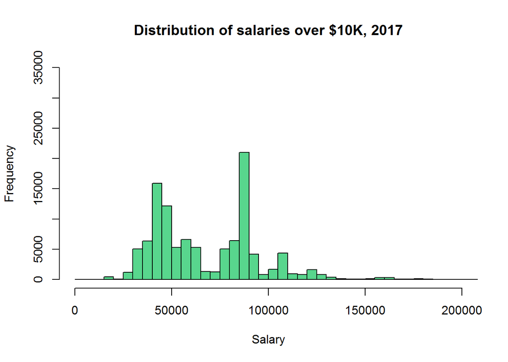

```r
hist(df17$sal,
     main ="Distribution of salaries over $10K, 2017",
     xlab="Salary",
     border="black",
     col="#58D68D",
     xlim=c(0,200000),
     ylim=c(0,35000),
     breaks = seq(0, 350000, by = 5000)
     #prob=TRUE
     #breaks=c(0,10000,20000,30000,40000,50000,60000,70000,80000,90000,100000,110000,120000,130000,350000)
     )
```

### 5.0.6 Plot - All Titles - Salaries between 85K and 90K

```r
df5<- data.frame(read.csv("titles17-8590k.csv"),stringsAsFactors = FALSE)

df5 %>% mutate_if(is.factor, as.character) -> df5

p4 <- df5 %>%
  plot_ly(labels = ~Description, values = ~n) %>%
  add_pie(hole = 0.6) %>%
  layout(title = "Titles between $85K and $90K",  showlegend = T,
         xaxis = list(showgrid = FALSE, zeroline = FALSE, showticklabels = FALSE),
         yaxis = list(showgrid = FALSE, zeroline = FALSE, showticklabels = FALSE))

p4
```

[interactive chart not shown]

Best opportunities for promotion within the same title

# 6 Correlations

# 7 Export files

Export:

Subset of selected 20 titles.

Summary of salaries by title with year over year comparisons.

Summary of salaries by agency with year over year comparisons.

Headcount by agency, wide format

Average salary by title, long format

Percent headcount increases by agency

2017 payroll only, complete cases, all titles

```r
#changed to eval=FALSE after first run.

#subset of selected titles only
write.csv(dfsub1, file = "dfsub1.csv")

#average salary comparison with one column for each year
write.csv(salbytitle3, file = "sal-title-year-comparison.csv")

#headcount by agency with one column for each year
write.csv(headcountbyagency, file = "headcount-agency-year-comparison.csv")

#average salary comparison with years in one column
write.csv(salbytitle2, file = "sal-title-year-comparison-long.csv")

#headcount and average salary by agency with years in one column
write.csv(salbyagency1, file = "sal-agency-year-comparison-long.csv")

#percent headcount increases by agency
write.csv(headcountbyagency, file = "headcountbyagency-pct-increase.csv")

#2017 payroll only, complete cases, all titles
write.csv(df17, file = "df17.csv")
```